# HW 4 Explore a Single Variable - Guide

```r
library(dplyr)
library(ggplot2)
library(janitor)
library(kableExtra)
```

```r
theme_update(plot.title = element_text(hjust = 0.5))
```

```r
load("/cloud/project/data/demo_addhealth_clean.Rdata")
```

# Table of Variables

| Original Variable | New Variable | Description |
| --- | --- | --- |
| RACE | race_c | subject’s race |
| BIO_SEX4 | gender | subject’s gender |
| – | age | subject’s age |
| H4ED2 | college_deg | Dd you complete college (bachelor’s degree)? |
| H4DA11 | vigorous_activity | In the past 24 hours, have you participated in vigorous physical activity long enough to work up a sweat, get your heart thumping, or get out of breath? |
| H4MH23 | too_tired | (During the past seven days:) You felt that you were too tired to do things. |
| H4LM19 | hrs_worked_week | How many hours a week (do/did) you usually work at this job? |

# Examing categorical variable

## 1st Categorical `vigorous_activity`

**Numerical Summary Table**

```r
clean %>%
  tabyl(vigorous_activity) %>%
  adorn_pct_formatting(digits=1) %>%
  adorn_totals()%>%
  kable() %>%
  kable_styling(full_width = F, position="center")
```

vigorous_activity

n

percent

valid_percent

no

3056

59.8%

59.8%

yes

2055

40.2%

40.2%

refused

1

0.0%

0.0%

don’t know

1

0.0%

0.0%

NA

1

0.0%

Total

5114

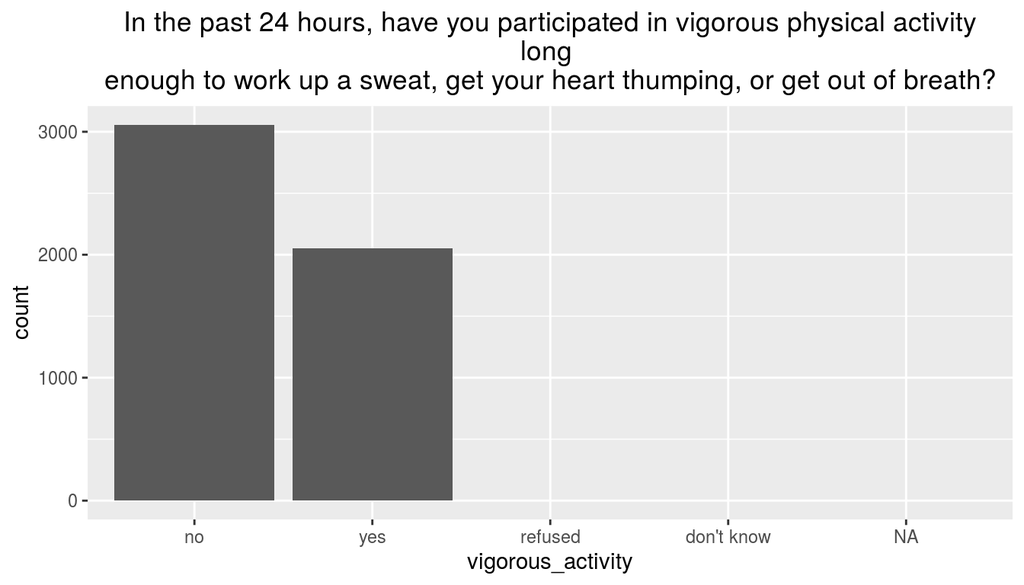

```r
clean %>%
  #filter(vigorous_activity=="yes" | vigorous_activity=="no") %>%
  ggplot(aes(x=vigorous_activity)) +
  geom_bar() +
  ggtitle("In the past 24 hours, have you participated in vigorous physical activity
long
enough to work up a sweat, get your heart thumping, or get out of breath?")
```

**Narrative summary**

The participants in the **addhealth** study were asked, “*In the past 24 hours, have you participated in vigorous physical activity long enough to work up a sweat, get your heart thumping, or get out of breath?*” **5111** out of **5114** provided a “yes” or “no” response, with approximately **40%** of the participant responding **yes**. Approximately **2 out of 5** participants have participated in a vigorous activity in the past 24 hours.

# Examining numerical variable

## 1st Numerical `hrs_work_week`

**Numerical Summary Table**

```r
hours <- clean %>%
  filter(hrs_work_week < 121) %>%
  summarize(n = n(),
            min = min(hrs_work_week),
            q1 = quantile(hrs_work_week, probs=0.25),
            median = median(hrs_work_week),
            mean = mean(hrs_work_week),
            q3 = quantile(hrs_work_week, probs=0.75),
            max = max(hrs_work_week),
            sd = sd(hrs_work_week))

kable(round(hours,1)) %>%
kable_styling(full_width = F, position="center")
```

| n | min | q1 | median | mean | q3 | max | sd |
| --- | --- | --- | --- | --- | --- | --- | --- |
| 5023 | 10 | 40 | 40 | 41.2 | 45 | 120 | 11.4 |

**Histogram - visualization of the distribution**

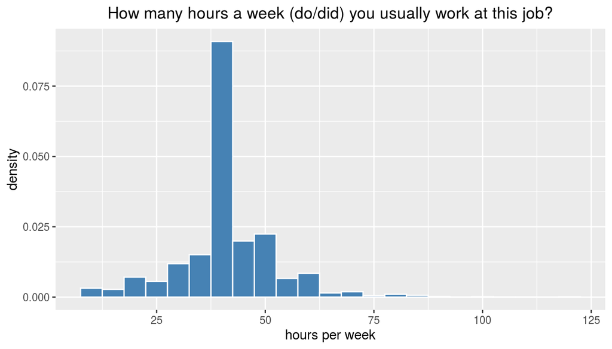

```r
clean %>%
  filter(hrs_work_week < 121) %>%
  ggplot(aes(x=hrs_work_week)) +
    geom_histogram(aes(y=..density..), color="white", fill="steelblue", binwidth = 5) +
      xlab("hours per week") +
      ggtitle("How many hours a week (do/did) you usually work at this job?")
```

**Boxplot - visualization of 5 number summary**

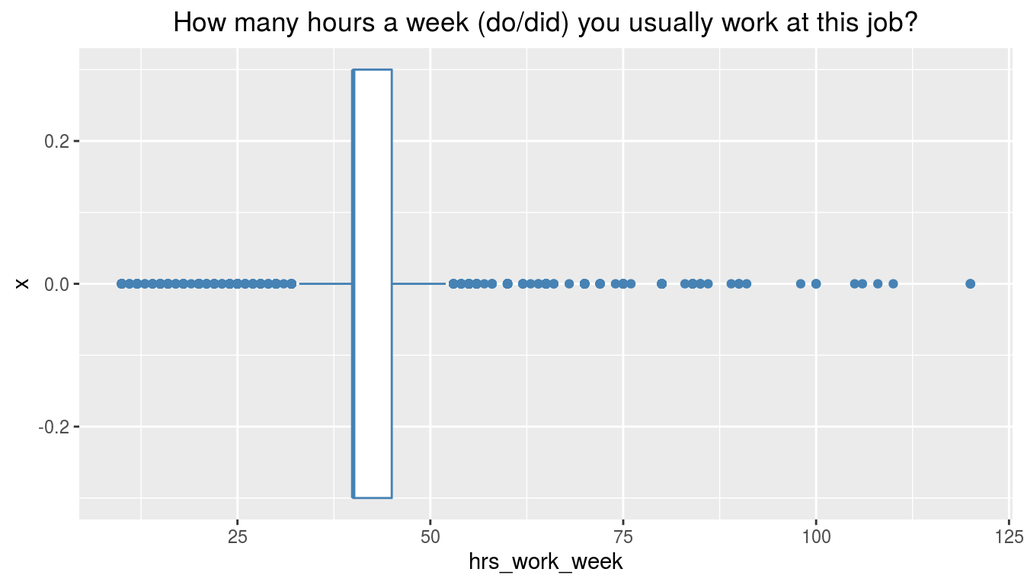

```r
clean %>%
  filter(hrs_work_week < 121) %>%
  ggplot(aes(y=hrs_work_week, x=0)) +
    geom_boxplot(color="steelblue", width=0.6) +
      ggtitle("How many hours a week (do/did) you usually work at this job?")+
  coord_flip()
```

**Narrative Summary**

Participants were asked, in reference to their curren or most recent job (which they work more than 10 hours/week), “*How many hours a week (do/did) you usually work at this job?*”

- **5023** out of **5114** responded with hours between 10 and 120.
- **82** participants were a **legitimate skip** since they have not worked a paying job for at least 10 hours a week, they are not represented here.

The center of the distribution is best described with the **mode** and **median** of 40 hours/week. There is considerable overall variation as hours vary from 10 to 120, although the middle 50% of particpants are between 40 and 45 hours, for an interquartile range (**IQR**) of 5 hours. Weekly work hours is *slightly skewed to the **right*** (since outliers extend, to the right, to 120 hours). This skew also results in the **mean** being greater than the **median**, which is a typically characteristic of right skewed distributions.